# Project: Investigate a Dataset (Replace this with something more specific!)

```python
#Step 1 Converting 'AppointmentDay' and 'SchdularedDay'format  into datetime

def todatetime(x):
    df[x]=pd.to_datetime(df[x])
    df[x]=df[x].apply(lambda x:datetime.date(x))
    print(x,df[x][1])
    return
```

```python
todatetime('AppointmentDay')
todatetime('ScheduledDay')
```

```
('AppointmentDay', datetime.date(2016, 4, 29))
('ScheduledDay', datetime.date(2016, 4, 29))
```

```python
#Step 2 :Adding new column'Time_interval'to indicate the time cap between
#scheduledDay and AppointmentDay

df['Time_interval']=df.apply(lambda x:(x[4]-x[3]).days,axis=1)

#check new column, it shows as the last column of dataset
df.head(2)
```

|  | PatientId | AppointmentID | Gender | ScheduledDay | AppointmentDay | Age | Neighbourhood | Scholarship | Hipertension | Diabetes | Alcoholism | Handcap | SMS_received | No-show | Time_interval |
| --- | --- | --- | --- | --- | --- | --- | --- | --- | --- | --- | --- | --- | --- | --- | --- |
| 0 | 2.987250e+13 | 5642903 | F | 2016-04-29 | 2016-04-29 | 62 | JARDIM DA PENHA | 0 | 1 | 0 | 0 | 0 | 0 | No | 0 |
| 1 | 5.589978e+14 | 5642503 | M | 2016-04-29 | 2016-04-29 | 56 | JARDIM DA PENHA | 0 | 0 | 0 | 0 | 0 | 0 | No | 0 |

```python
#check the dataset, found the error value:the min age and min time interval cannot have negtive value.
#Because the appointment day must equals or after the schduled day.
df.describe()
```

|  | PatientId | AppointmentID | Age | Scholarship | Hipertension | Diabetes | Alcoholism | Handcap | SMS_received | Time_interval |
| --- | --- | --- | --- | --- | --- | --- | --- | --- | --- | --- |
| count | 1.105270e+05 | 1.105270e+05 | 110527.000000 | 110527.000000 | 110527.000000 | 110527.000000 | 110527.000000 | 110527.000000 | 110527.000000 | 110527.000000 |
| mean | 1.474963e+14 | 5.675305e+06 | 37.088874 | 0.098266 | 0.197246 | 0.071865 | 0.030400 | 0.022248 | 0.321026 | 10.183702 |
| std | 2.560949e+14 | 7.129575e+04 | 23.110205 | 0.297675 | 0.397921 | 0.258265 | 0.171686 | 0.161543 | 0.466873 | 15.254996 |
| min | 3.921784e+04 | 5.030230e+06 | -1.000000 | 0.000000 | 0.000000 | 0.000000 | 0.000000 | 0.000000 | 0.000000 | -6.000000 |
| 25% | 4.172614e+12 | 5.640286e+06 | 18.000000 | 0.000000 | 0.000000 | 0.000000 | 0.000000 | 0.000000 | 0.000000 | 0.000000 |
| 50% | 3.173184e+13 | 5.680573e+06 | 37.000000 | 0.000000 | 0.000000 | 0.000000 | 0.000000 | 0.000000 | 0.000000 | 4.000000 |
| 75% | 9.439172e+13 | 5.725524e+06 | 55.000000 | 0.000000 | 0.000000 | 0.000000 | 0.000000 | 0.000000 | 1.000000 | 15.000000 |
| max | 9.999816e+14 | 5.790484e+06 | 115.000000 | 1.000000 | 1.000000 | 1.000000 | 1.000000 | 4.000000 | 1.000000 | 179.000000 |

```python
#drop the error rows that have negtive time_interval and negtive age.and check again,
#min age is 0,min time interval is 0
df=df.query('(Time_interval>=0)and(Age>=0)')
df.describe()
```

|  | PatientId | AppointmentID | Age | Scholarship | Hipertension | Diabetes | Alcoholism | Handcap | SMS_received | Time_interval |
| --- | --- | --- | --- | --- | --- | --- | --- | --- | --- | --- |
| count | 1.105210e+05 | 1.105210e+05 | 110521.000000 | 110521.000000 | 110521.000000 | 110521.000000 | 110521.000000 | 110521.000000 | 110521.000000 | 110521.000000 |
| mean | 1.474906e+14 | 5.675304e+06 | 37.089386 | 0.098271 | 0.197257 | 0.071869 | 0.030401 | 0.022231 | 0.321043 | 10.184345 |
| std | 2.560860e+14 | 7.129691e+04 | 23.109885 | 0.297682 | 0.397929 | 0.258272 | 0.171690 | 0.161494 | 0.466879 | 15.255153 |
| min | 3.921784e+04 | 5.030230e+06 | 0.000000 | 0.000000 | 0.000000 | 0.000000 | 0.000000 | 0.000000 | 0.000000 | 0.000000 |
| 25% | 4.172457e+12 | 5.640284e+06 | 18.000000 | 0.000000 | 0.000000 | 0.000000 | 0.000000 | 0.000000 | 0.000000 | 0.000000 |
| 50% | 3.173185e+13 | 5.680573e+06 | 37.000000 | 0.000000 | 0.000000 | 0.000000 | 0.000000 | 0.000000 | 0.000000 | 4.000000 |
| 75% | 9.438963e+13 | 5.725524e+06 | 55.000000 | 0.000000 | 0.000000 | 0.000000 | 0.000000 | 0.000000 | 1.000000 | 15.000000 |
| max | 9.999816e+14 | 5.790484e+06 | 115.000000 | 1.000000 | 1.000000 | 1.000000 | 1.000000 | 4.000000 | 1.000000 | 179.000000 |

```python
#Step 3:. Drop 'Hipertension','Diabetes','Alcoholism','Handcap'
#'Scholarship','SMS_received' cloumns which we won't use in this report

df.drop(['Hipertension','Diabetes','Alcoholism','Handcap','Neighbourhood','Scholarship','SMS_received'],axis=1,inplace=True)

#check dataset whether correctly drop columns we don't need.
df.head(2)
```

|  | PatientId | AppointmentID | Gender | ScheduledDay | AppointmentDay | Age | No-show | Time_interval |
| --- | --- | --- | --- | --- | --- | --- | --- | --- |
| 0 | 2.987250e+13 | 5642903 | F | 2016-04-29 | 2016-04-29 | 62 | No | 0 |
| 1 | 5.589978e+14 | 5642503 | M | 2016-04-29 | 2016-04-29 | 56 | No | 0 |

```python
#Step 4: Rename 'No-show' to 'No_show'.
df=df.rename(columns={'No-show':'No_show'})

#check the name of 'No_show' column
df.head(1)
```

|  | PatientId | AppointmentID | Gender | ScheduledDay | AppointmentDay | Age | No_show | Time_interval |
| --- | --- | --- | --- | --- | --- | --- | --- | --- |
| 0 | 2.987250e+13 | 5642903 | F | 2016-04-29 | 2016-04-29 | 62 | No | 0 |

## Exploratory Data Analysis

> **Tip**: Now that you've trimmed and cleaned your data, you're ready to move on to exploration. Compute statistics and create visualizations with the goal of addressing the research questions that you posed in the Introduction section. It is recommended that you be systematic with your approach. Look at one variable at a time, and then follow it up by looking at relationships between variables.

### Research Question 1 :Whether the time interval between the Schduled day and appointment day will influence the patient not show up?

```python
# Get a new sub dateframe 'df_ns' only contains the no show patients
df_ns=df.query('No_show=="Yes"')
df_ns.head(3)
```

|  | PatientId | AppointmentID | Gender | ScheduledDay | AppointmentDay | Age | No_show | Time_interval |
| --- | --- | --- | --- | --- | --- | --- | --- | --- |
| 6 | 7.336882e+14 | 5630279 | F | 2016-04-27 | 2016-04-29 | 23 | Yes | 2 |
| 7 | 3.449833e+12 | 5630575 | F | 2016-04-27 | 2016-04-29 | 39 | Yes | 2 |
| 11 | 7.542951e+12 | 5620163 | M | 2016-04-26 | 2016-04-29 | 29 | Yes | 3 |

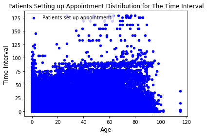

```python
df.plot(x='Age',y='Time_interval',kind='scatter',color='b',label='Patients set up appointment')
plt.ylabel('Time Interval ',fontsize=12)
plt.xlabel('Age',fontsize=12)
plt.title('Patients Setting up Appointment Distribution for The Time Interval')
plt.legend()
```

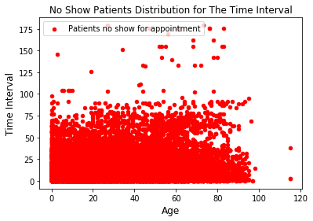

```python
df_ns.plot(x='Age',y='Time_interval',kind='scatter',color='r',label='Patients no show for appointment')

plt.ylabel('Time Interval',fontsize=12)
plt.xlabel('Age',fontsize=12)
plt.title('No Show Patients Distribution for The Time Interval')
plt.legend()
```

Time interval indicates the days gap between the scheduled day and appointment day.

We can see from above figures: The Number of all setting schdule patients and no show up patient are both descrease with time interval becoming longer.

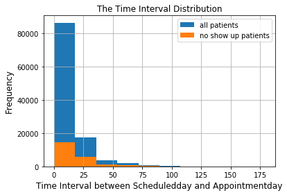

```python
df['Time_interval'].hist(figsize=(6,4),label='all patients')
df_ns['Time_interval'].hist(figsize=(6,4),label='no show up patients')
plt.xlabel('Time Interval between Scheduledday and Appointmentday',fontsize=12)
plt.ylabel('Frequency',fontsize=12)
plt.title('The Time Interval Distribution')
plt.legend()
```

We can see from above figures: The descrease tend of all setting schduled patients is more sharply than the descrease tend of no show patients

Next, I cut the time interval into four levels: short, medium, long, superlong. And to see the patients distribution in those four levels.

```python
df.describe()
```

|  | PatientId | AppointmentID | Age | Time_interval |
| --- | --- | --- | --- | --- |
| count | 1.105210e+05 | 1.105210e+05 | 110521.000000 | 110521.000000 |
| mean | 1.474906e+14 | 5.675304e+06 | 37.089386 | 10.184345 |
| std | 2.560860e+14 | 7.129691e+04 | 23.109885 | 15.255153 |
| min | 3.921784e+04 | 5.030230e+06 | 0.000000 | 0.000000 |
| 25% | 4.172457e+12 | 5.640284e+06 | 18.000000 | 0.000000 |
| 50% | 3.173185e+13 | 5.680573e+06 | 37.000000 | 4.000000 |
| 75% | 9.438963e+13 | 5.725524e+06 | 55.000000 | 15.000000 |
| max | 9.999816e+14 | 5.790484e+06 | 115.000000 | 179.000000 |

```python
# Bin edges that will be used to "cut" the data into groups
#according to the above 25% 50% 75% value of Time_interval
bin_edges = [-0.01,0,4,15,50 ]
```

```python
# Labels for the four time interval level groups
bin_names = ['short','medium', 'long', 'superlong' ]
```

```python
def cuttimelevel(fn):
    fn['Time_interval_levels'] = pd.cut(fn['Time_interval'], bin_edges, labels=bin_names)
    return fn.head(5)
```

```python
cuttimelevel(df)
```

|  | PatientId | AppointmentID | Gender | ScheduledDay | AppointmentDay | Age | No_show | Time_interval | Time_interval_levels |
| --- | --- | --- | --- | --- | --- | --- | --- | --- | --- |
| 0 | 2.987250e+13 | 5642903 | F | 2016-04-29 | 2016-04-29 | 62 | No | 0 | short |
| 1 | 5.589978e+14 | 5642503 | M | 2016-04-29 | 2016-04-29 | 56 | No | 0 | short |
| 2 | 4.262962e+12 | 5642549 | F | 2016-04-29 | 2016-04-29 | 62 | No | 0 | short |
| 3 | 8.679512e+11 | 5642828 | F | 2016-04-29 | 2016-04-29 | 8 | No | 0 | short |
| 4 | 8.841186e+12 | 5642494 | F | 2016-04-29 | 2016-04-29 | 56 | No | 0 | short |

```python
#show up patients dataset 'df_s'
df_s=df.query('No_show=="No"')
df_s.head(3)
```

|  | PatientId | AppointmentID | Gender | ScheduledDay | AppointmentDay | Age | No_show | Time_interval | Time_interval_levels |
| --- | --- | --- | --- | --- | --- | --- | --- | --- | --- |
| 0 | 2.987250e+13 | 5642903 | F | 2016-04-29 | 2016-04-29 | 62 | No | 0 | short |
| 1 | 5.589978e+14 | 5642503 | M | 2016-04-29 | 2016-04-29 | 56 | No | 0 | short |
| 2 | 4.262962e+12 | 5642549 | F | 2016-04-29 | 2016-04-29 | 62 | No | 0 | short |

```python
#no show patients dataset 'df_ns'
df_ns=df.query('No_show=="Yes"')
df_ns.head(3)
```

|  | PatientId | AppointmentID | Gender | ScheduledDay | AppointmentDay | Age | No_show | Time_interval | Time_interval_levels |
| --- | --- | --- | --- | --- | --- | --- | --- | --- | --- |
| 6 | 7.336882e+14 | 5630279 | F | 2016-04-27 | 2016-04-29 | 23 | Yes | 2 | medium |
| 7 | 3.449833e+12 | 5630575 | F | 2016-04-27 | 2016-04-29 | 39 | Yes | 2 | medium |
| 11 | 7.542951e+12 | 5620163 | M | 2016-04-26 | 2016-04-29 | 29 | Yes | 3 | medium |

```python
# Creates new column to show time interval levels
df['Time_interval_levels'] = pd.cut(df['Time_interval'], bin_edges, labels=bin_names)
```

```python
#Check the dataset again, and can see the four level in the last new column
df.head(10)
```

|  | PatientId | AppointmentID | Gender | ScheduledDay | AppointmentDay | Age | No_show | Time_interval | Time_interval_levels |
| --- | --- | --- | --- | --- | --- | --- | --- | --- | --- |
| 0 | 2.987250e+13 | 5642903 | F | 2016-04-29 | 2016-04-29 | 62 | No | 0 | short |
| 1 | 5.589978e+14 | 5642503 | M | 2016-04-29 | 2016-04-29 | 56 | No | 0 | short |
| 2 | 4.262962e+12 | 5642549 | F | 2016-04-29 | 2016-04-29 | 62 | No | 0 | short |
| 3 | 8.679512e+11 | 5642828 | F | 2016-04-29 | 2016-04-29 | 8 | No | 0 | short |
| 4 | 8.841186e+12 | 5642494 | F | 2016-04-29 | 2016-04-29 | 56 | No | 0 | short |
| 5 | 9.598513e+13 | 5626772 | F | 2016-04-27 | 2016-04-29 | 76 | No | 2 | medium |
| 6 | 7.336882e+14 | 5630279 | F | 2016-04-27 | 2016-04-29 | 23 | Yes | 2 | medium |
| 7 | 3.449833e+12 | 5630575 | F | 2016-04-27 | 2016-04-29 | 39 | Yes | 2 | medium |
| 8 | 5.639473e+13 | 5638447 | F | 2016-04-29 | 2016-04-29 | 21 | No | 0 | short |
| 9 | 7.812456e+13 | 5629123 | F | 2016-04-27 | 2016-04-29 | 19 | No | 2 | medium |

Next, I will pick out two sub dataframe from df : one is no show patients dataset 'df_ns', and the other one is show up patients dataset 'df_s'. Then calculate the no show patient proportion in each four time interval levels.

```python
# calculate proportions of fz in total patient fm
def count_TIL(fz,fm):
    #count the totoal number of patients groupby time interval level(TIL)
    total_z=fz.groupby('Time_interval_levels').count().No_show
    total_m=fm.groupby('Time_interval_levels').count().No_show
    prop_fnm=total_z/total_m
    return prop_fnm
```

```python
Time_n_proportions=count_TIL(df_ns,df) # get proportions of no show patient in total patient
Time_n_proportions
```

```
Time_interval_levels
short        0.046471
medium       0.229902
long         0.285381
superlong    0.330262
Name: No_show, dtype: float64
```

```python
Time_s_proportions=count_TIL(df_s,df) # get proportions of show up patient in total patient
Time_s_proportions
```

```
Time_interval_levels
short        0.953529
medium       0.770098
long         0.714619
superlong    0.669738
Name: No_show, dtype: float64
```

```python
ind = np.arange(len(Time_s_proportions))  # the x locations for the groups
width = 0.35       # the width of the bars
```

[figure not shown]

```python
# plot bars to compare the proportion of no show patients to showup patients' proportion
#in each four different time intervel levels.

ns_bars = plt.bar(ind, Time_n_proportions, width, color='r', alpha=.7, label='No Show')
s_bars = plt.bar(ind + width, Time_s_proportions, width, color='b', alpha=.7, label='Show Up')

# title and labels
plt.ylabel('Proportion')
plt.xlabel('Time Interval Level')
plt.title('Proportion by Time Interval Longth')
locations = ind + width / 2  # xtick locations
labels = ['Short', 'Medium', 'Long', 'Superlong']  # xtick labels
plt.xticks(locations, labels)

# legend
plt.legend()
```

From the above figure, we can see the no show proportion is keeping increase with the time intervel becoming longer,while the show up patient proportion is descreasing.

Next, I will calculate the mean of time interval for no show patients and show up patients.

```
No_show
No      8.754759
Yes    15.835484
Name: Time_interval, dtype: float64
```

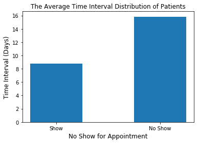

```python
ts_mean=df.groupby(['No_show']).Time_interval.mean()
plt.subplots(figsize=(6,4))
plt.bar(ts_mean.index, ts_mean,width=0.5,align='center')

plt.ylabel('Time Interval (Days)',fontsize=12)
plt.xlabel('No Show for Appointment',fontsize=12)
plt.xticks(['No','Yes'],['Show','No Show'])
plt.title('The Average Time Interval Distribution of Patients')
print (ts_mean)
```

From above figure,we can see the no show patients likely had longer time interval between the schdule day and appointment day. No show patients' time interval mean is around 16 days, while the show up patients' time interval mean value is around 9 days.

### Research Question 2: Whether the gender is the important factor for us to predict if a patient will show up for appointment?

```python
Female=df.Gender=='F'
Male=df.Gender=='M'
Female_ns=df.Gender=='F'
Male_ns=df.Gender=='M'

Show=df.No_show=='No'
No_Show=df.No_show=='Yes'
```

```
Text(0.5,1,'Distribution of Patients')
```

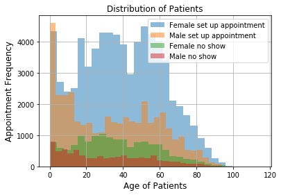

```python
#plot two gender distribution
df.Age[Female].hist(alpha=0.5,bins=30,label='Female set up appointment')
df.Age[Male].hist(alpha=0.5,bins=30,label='Male set up appointment')
df_ns.Age[Female_ns].hist(alpha=0.5,bins=30,label='Female no show')
df_ns.Age[Male_ns].hist(alpha=0.5,bins=30,label='Male no show')

plt.legend()
plt.ylabel('Appointment Frequency',fontsize=12)
plt.xlabel('Age of Patients',fontsize=12)
plt.title('Distribution of Patients')
```

From above figure, we can see:

1. More female patients set up appointment than male patients.
2. Also more female no show up for the schduled appointment than male patients.

```python
#calculate the percentage of female and male no show after setting up appointments
def percent_ns_set(fz,gender):
    if gender=='F':
# count each gender patients of made scheduled appointment
        set_g=df.query('Gender=="F"').PatientId.count()
#count each gender patients of no show up for appointment
        ns_f=df_ns.query('Gender=="F"').PatientId.count()

    else:
        set_g=df.query('Gender=="M"').PatientId.count()
        ns_f=df_ns.query('Gender=="M"').PatientId.count()

# calculate the percentage
    p=float(ns_f)/(set_g)
    return p
```

```python
pf=percent_ns_set(df,'F')#female no show percentage
```

```python
pm=percent_ns_set(df,'M')# male no show percentage
```

```python
# the percentage of female and male no show after appointment
print (pf,pm)       # the percentage of each is very similar
```

```
(0.2031154295896208, 0.19963810262375598)
```

```
Text(0.5,1,'No Show Patient Percentage')
```

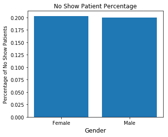

```python
#plot the percentage of no show female and male:  (no show female)/(set up female) ,(no show male)/(set up male)
ns_r=pd.Series([pf,pm])
ns_r.index=['Female','Male']
plt.subplots(figsize=(5,4))
plt.bar(ns_r.index, ns_r)
plt.xlabel('Gender',fontsize=12)
plt.ylabel('Percentage of No Show Patients')
plt.title('No Show Patient Percentage')
```

From the above figure, we can see that both gender have the similar percentage of not showing in schduled appointment. So,gender is not the important factor for us to predict if a patient will show up for appointment.

## Conclusions

> **Tip**: Finally, summarize your findings and the results that have been performed. Make sure that you are clear with regards to the limitations of your exploration. If you haven't done any statistical tests, do not imply any statistical conclusions. And make sure you avoid implying causation from correlation!

> **Tip**: Once you are satisfied with your work, you should save a copy of the report in HTML or PDF form via the **File** > **Download as** submenu. Before exporting your report, check over it to make sure that the flow of the report is complete. You should probably remove all of the "Tip" quotes like this one so that the presentation is as tidy as possible. Congratulations!

**Answer for the questions**

1. The longer time interval between shcduled day and appointment day, the higher possibility that patient won't show for appointment.
2. Gender is not a important factor for us to predict if a patient will show up for appointment.

**Limitations**

The dataset is only collected four kinds of illness('Hipertension','Diabetes','Alcoholism','Handcap'), this limitation makes the results of analyze only can show the patients showing up behavior in this small scope. So, this sample doesn't represent the all patients behavior.